# STAT431: Intro To R

Raiden Hasegawa

Fall 2016

# Before We Start

There is much more information here than you will actually need for this course (STAT 431) but you can use it as an additional reference. If you want to run and compile this R markdown file into a nice html like this, follow the instructions in `getting_started.rtf`. If you just want the R code that was run in this file, take a look at the `R_tutorial_insession.R` script in this directory.

# Installing R

The easiest way to get the R environment up and running on your system is to insall a precompiled binary distribution from http://lib.stat.cmu.edu/R/CRAN/, Choose the binary for your system and the step by step instructions should be just like installing any other application.

# Installing RStudio

RStudio is an excellent GUI for coding in R. It integrates the command line, graphical file directory explorer, graphical environment/variable inspector, and figure/plot output. I suggest that you install the binary file to your machine. You can find the download link at https://www.rstudio.com/products/rstudio/download/ under the *Installers for Supported Platforms* list. Choose the link that corresponds to your OS. The installation should be just like installing any other program from the web at this point.

# Preliminaries

We’ll start with some pretty important basic commands you will need to get you up and started in R.

## A few basic notes on syntax and creating an R document

After opening up RStudio you will want to open a new R Script by going to `File > New File > R Script`. We can now input code (to be executed) and comments (to describe the code) into your script which we can evaluate in our current R session. You can also enter commands directly into the Console but for complicated analysis you want to be able to reproduce, you’ll want to write your analysis in a script you can run again and again.

```r
# This is a comment
x <- pi # this assigns the variable x the value π
paste("π is approximately",x) # this concatenates strings separated by spaces
```

```
## [1] "π is approximately 3.14159265358979"
```

```r
# these two operations do the same thing:
x <- cos(pi) # prefered syntax
x =  cos(pi)
```

You can evaluate code in your script several ways:

- Evaluate current line: `cmd`+`ret`
- Evaluate selection by selecting code block and using the keystroke combo above
- Evaluate entire script: `opt`+`cmd`+`R`

Here are a few more nice key shortcuts:

- Move cursor to script editor: `ctrl` + `1`
- Move cursor to console editor: `ctrl` + `2`
- Clear the console: `ctrl` + `L`

## Setting your working directory

Your working director is where R will find and save data files, plots, etc.

```r
getwd()                # Get your current working directory
```

```
## [1] "/Users/raidenhasegawa/TA/STAT471/R_Tutorial_STAT471"
```

```r
setwd("~/TA/STAT471/R_Tutorial_STAT471") # Set working directory (where R will search for files)
# or...
dir <- "~/TA/STAT471/R_Tutorial_STAT471"
setwd(dir)             # pass the string variable dir to setwd()
```

Here’s an example of how to read in a .csv data file located in your working directory:

```r
    radio=read.csv("Survey_results_final.csv", header=T, na.strings="")
  # comma is default seperator for read.csv: sep=","
  # with some different options now
    radio=read.csv("Survey_results_final.csv",header=T, stringsAsFactors=F,as.is=T, na.strings="")
```

## HELP!!! How to get it

Getting help is pretty straightforward in R. Here are a few ways to get help on the function we just saw. The first three commands don’t output anything to your command line but open up a help file in the help viewer.

```r
?read.csv
??read.csv
help(read.csv)
apropos("read") #   List all the functions with "read" as part of the function. Very useful!
```

```
##  [1] ".readRDS"         "read.csv"         "read.csv2"
##  [4] "read.dcf"         "read.delim"       "read.delim2"
##  [7] "read.DIF"         "read.fortran"     "read.ftable"
## [10] "read.fwf"         "read.socket"      "read.table"
## [13] "readBin"          "readChar"         "readCitationFile"
## [16] "readline"         "readLines"        "readRDS"
## [19] "readRenviron"     "Sys.readlink"
```

```r
# google: R: how to import a data set?
# If you pair "R" with some phrase related
# to stats or data google usually does a good job

args(read.csv) # list all the arguments
```

```
## function (file, header = TRUE, sep = ",", quote = "\"", dec = ".",
##     fill = TRUE, comment.char = "", ...)
## NULL
```

```r
str(read.csv)  # string representation of read.csv function
```

```
## function (file, header = TRUE, sep = ",", quote = "\"", dec = ".",
##     fill = TRUE, comment.char = "", ...)
```

```r
# ... both of these show you the defaul arguments (if there are any)
```

## Packages: what are they and how to install them

We will be using many statistical and machine learning algorithms, plotting functions, and datasets that are not available in the base distribution of R. R is an open source statistical language so many contributors write statistical packages that have functions that allow us to apply the algorithms we learn about in class to actual data!

```r
# Many packages available. We only need a few.
if(!any(installed.packages()[,1]=="MASS")) install.packages("MASS")
library(MASS)       # load package MASS
help(package=MASS)  # get information about MASS

installed.packages()[1:10,1] # packages installed (first 10)
```

```
##       bitops      caTools   colorspace    dichromat       digest
##     "bitops"    "caTools" "colorspace"  "dichromat"     "digest"
##     evaluate      formatR      ggplot2    gridExtra       gtable
##   "evaluate"    "formatR"    "ggplot2"  "gridExtra"     "gtable"
```

```r
pckgs.all <- available.packages("http://cran.r-project.org/bin/windows/contrib/3.2")
# get all the package with "knn" as part of the name
grep("knn", rownames(pckgs.all), val=T)
```

```
## [1] "kknn"      "knnGarden" "knnIndep"  "knncat"    "rknn"
```

```r
# get first 10 packages with "plot" as part of the name
grep("plot", rownames(pckgs.all), val=T )[1:10]
```

```
##  [1] "CMplot"                "Correlplot"
##  [3] "Eplot"                 "GGEBiplotGUI"
##  [5] "GOplot"                "Methplot"
##  [7] "NominalLogisticBiplot" "OrdinalLogisticBiplot"
##  [9] "PLSbiplot1"            "ROMIplot"
```

# Cleaning and examining the data

Before you conduct your analysis it is always wise to take a quick look at the data and try to spot anything abnormal such as missing data.

## Quick Check

In R, data is usually stored in an object called a data.frame. Each row is an observation and each column is a variable/feature.

```r
class(radio)
```

```
## [1] "data.frame"
```

```r
str(radio) # make sure the variables are correctly defined.
```

## Get a table view

If our dataset is not too big, we can graphically inspect the data in an Excel-like table with

```r
View(radio) # note that case matters in R
```

## Inspect the first (or last) few rows

This doesn’t display nicely when there are a lot of columns.

```r
head(radio) # or tail(radio), or head(radio,10) -- the first 10 rows
```

In this case, the graphical `View()` command is a better option.

## Find the size of the data or the numbers or rows and columns

```r
dim(radio)
```

```
## [1] 1764   35
```

## Get the variable names

```r
names(radio)[1:10] # hear we look at only the first 10
```

```
##  [1] "HITId"                       "HITTypeId"
##  [3] "Title"                       "Description"
##  [5] "Keywords"                    "Reward"
##  [7] "CreationTime"                "MaxAssignments"
##  [9] "RequesterAnnotation"         "AssignmentDurationInSeconds"
```

## Work with a subset which includes relevant variables

Below we see one method of subsetting; we specify the desire columns to keep with a vector of column indices.

```r
radio1=radio[, c( 24,28:33)] # take columns 24, 28, ... 33
str(radio1)
```

```
## 'data.frame':    1764 obs. of  7 variables:
##  $ WorkTimeInSeconds     : int  12 25 13 33 13 24 32 19 20 89 ...
##  $ Answer.Age            : chr  "21" "56" "40" "52" ...
##  $ Answer.Education      : chr  "Some college, no diploma; or Associate’s degree" "Some college, no diploma; or Associate’s degree" "Graduate or professional degree" "Graduate or professional degree" ...
##  $ Answer.Gender         : chr  "Female" "Female" "Female" "Female" ...
##  $ Answer.HouseHoldIncome: chr  "$30,000 - $50,000" "$15,000 - $30,000" "$50,000 - $75,000" "Above $150,000" ...
##  $ Answer.Sirius.Radio   : chr  "No" "No" "Yes" "Yes" ...
##  $ Answer.Wharton.Radio  : chr  "No" "No" "No" "Yes" ...
```

```r
View(radio1)
head(radio1)
```

```r
dim(radio1)
```

```
## [1] 1764    7
```

```r
summary(radio1)
```

```
##  WorkTimeInSeconds  Answer.Age        Answer.Education
##  Min.   :  4.0     Length:1764        Length:1764
##  1st Qu.: 17.0     Class :character   Class :character
##  Median : 21.0     Mode  :character   Mode  :character
##  Mean   : 22.5
##  3rd Qu.: 26.0
##  Max.   :108.0
##  Answer.Gender      Answer.HouseHoldIncome Answer.Sirius.Radio
##  Length:1764        Length:1764            Length:1764
##  Class :character   Class :character       Class :character
##  Mode  :character   Mode  :character       Mode  :character
##
##
##
##  Answer.Wharton.Radio
##  Length:1764
##  Class :character
##  Mode  :character
##
##
##
```

## rename the varables

```r
names(radio1)
```

```
## [1] "WorkTimeInSeconds"      "Answer.Age"
## [3] "Answer.Education"       "Answer.Gender"
## [5] "Answer.HouseHoldIncome" "Answer.Sirius.Radio"
## [7] "Answer.Wharton.Radio"
```

```r
names(radio1)=c("worktime", "age", "education", "gender", "income", "sirius", "wharton")
names(radio1)
```

```
## [1] "worktime"  "age"       "education" "gender"    "income"    "sirius"
## [7] "wharton"
```

```r
str(radio1) # Notice that age is not a continuous variable, why?
```

```
## 'data.frame':    1764 obs. of  7 variables:
##  $ worktime : int  12 25 13 33 13 24 32 19 20 89 ...
##  $ age      : chr  "21" "56" "40" "52" ...
##  $ education: chr  "Some college, no diploma; or Associate’s degree" "Some college, no diploma; or Associate’s degree" "Graduate or professional degree" "Graduate or professional degree" ...
##  $ gender   : chr  "Female" "Female" "Female" "Female" ...
##  $ income   : chr  "$30,000 - $50,000" "$15,000 - $30,000" "$50,000 - $75,000" "Above $150,000" ...
##  $ sirius   : chr  "No" "No" "Yes" "Yes" ...
##  $ wharton  : chr  "No" "No" "No" "Yes" ...
```

## Cleaning up the data: subsetting data

Sometimes data is coded improperly - numerical value recorded as a string, variable X recorded in column Y, etc. - and we need to correct this. Here we see a different type of subsetting; We provide a vector of booleans that are TRUE for the indices we are subsetting.

```r
summary(radio1)
```

```
##     worktime         age             education            gender
##  Min.   :  4.0   Length:1764        Length:1764        Length:1764
##  1st Qu.: 17.0   Class :character   Class :character   Class :character
##  Median : 21.0   Mode  :character   Mode  :character   Mode  :character
##  Mean   : 22.5
##  3rd Qu.: 26.0
##  Max.   :108.0
##     income             sirius            wharton
##  Length:1764        Length:1764        Length:1764
##  Class :character   Class :character   Class :character
##  Mode  :character   Mode  :character   Mode  :character
##
##
##
```

```r
levels(radio1$age)
```

```r
# need to take care of "27`", "Eighteen (18)", "female" and "223"
radio1$age[radio1$age == "27`"] <- 27
radio1$age[radio1$age == "Eighteen (18)"] <- 18
radio1$age[radio1$age == "female"] <- NA

radio1$age=as.character(radio1$age)
radio1$age=as.numeric(radio1$age)
```

## Summarizing data

We can use histograms (at least for continuous variables) and summary statistics to get a picture of the distribution of the features in our dataset.

```r
summary(radio1$age)
```

```
##    Min. 1st Qu.  Median    Mean 3rd Qu.    Max.    NA's
##    4.00   23.00   28.00   30.52   34.00  223.00       2
```

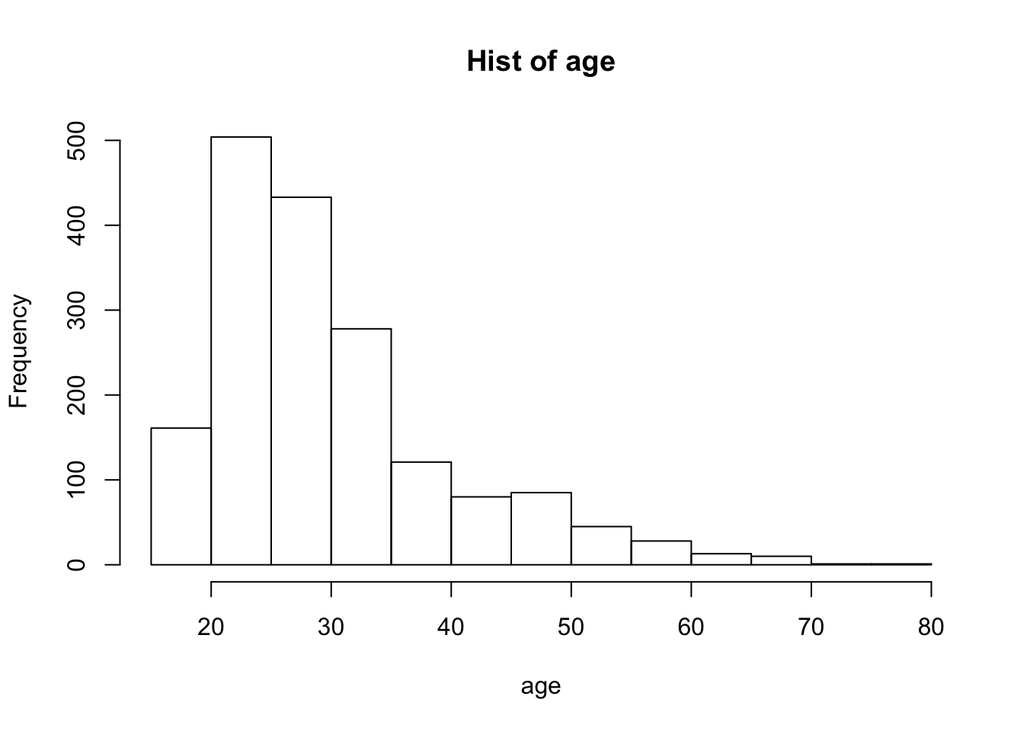

```r
radio2=radio1[(radio1$age >15) & (radio1$age < 100), ]
hist(radio2$age, breaks=10, main="Hist of age", xlab="age")
```

```r
# use a large number as break points to see the details
```

## Excluding missing data: more subsetting

Here we only want to consider data associated with Wharton and Sirius radio.

```r
radio1=radio1[!is.na(radio1$sirius),]
radio1=radio1[!(radio1$sirius==""),]
radio1=radio1[!is.na(radio1$wharton),]
radio1=radio1[!(radio1$wharton==""),]
dim(radio1)
```

```
## [1] 1757    7
```

```r
paste("The complete data has", dim(radio1)[1], "cases")
```

```
## [1] "The complete data has 1757 cases"
```

```r
str(radio1)
```

```
## 'data.frame':    1757 obs. of  7 variables:
##  $ worktime : int  12 25 13 33 13 24 32 19 20 89 ...
##  $ age      : num  21 56 40 52 33 55 24 40 35 62 ...
##  $ education: chr  "Some college, no diploma; or Associate’s degree" "Some college, no diploma; or Associate’s degree" "Graduate or professional degree" "Graduate or professional degree" ...
##  $ gender   : chr  "Female" "Female" "Female" "Female" ...
##  $ income   : chr  "$30,000 - $50,000" "$15,000 - $30,000" "$50,000 - $75,000" "Above $150,000" ...
##  $ sirius   : chr  "No" "No" "Yes" "Yes" ...
##  $ wharton  : chr  "No" "No" "No" "Yes" ...
```

## Check that each variable in data frame is of correct type

We want to make sure that the categorical variables are of class `factor`.

```r
radio1$wharton=as.factor(radio1$wharton)
radio1$sirius=as.factor(radio1$sirius)
radio1$gender=as.factor(radio1$gender)
radio1$income=as.factor(radio1$income)
str(radio1)
```

```
## 'data.frame':    1757 obs. of  7 variables:
##  $ worktime : int  12 25 13 33 13 24 32 19 20 89 ...
##  $ age      : num  21 56 40 52 33 55 24 40 35 62 ...
##  $ education: chr  "Some college, no diploma; or Associate’s degree" "Some college, no diploma; or Associate’s degree" "Graduate or professional degree" "Graduate or professional degree" ...
##  $ gender   : Factor w/ 2 levels "Female","Male": 1 1 1 1 2 2 1 1 1 1 ...
##  $ income   : Factor w/ 6 levels "$15,000 - $30,000",..: 2 1 3 5 2 2 2 3 6 2 ...
##  $ sirius   : Factor w/ 2 levels "No","Yes": 1 1 2 2 1 2 2 2 2 2 ...
##  $ wharton  : Factor w/ 2 levels "No","Yes": 1 1 1 2 1 1 1 1 1 1 ...
```

```r
summary(radio1)
```

```
##     worktime           age          education            gender
##  Min.   :  8.00   Min.   :  4.00   Length:1757        Female: 742
##  1st Qu.: 17.00   1st Qu.: 23.00   Class :character   Male  :1009
##  Median : 21.00   Median : 28.00   Mode  :character   NA's  :   6
##  Mean   : 22.52   Mean   : 30.53
##  3rd Qu.: 26.00   3rd Qu.: 34.00
##  Max.   :108.00   Max.   :223.00
##                   NA's   :1
##                 income    sirius     wharton
##  $15,000 - $30,000 :366   No : 399   No :1687
##  $30,000 - $50,000 :428   Yes:1358   Yes:  70
##  $50,000 - $75,000 :376
##  $75,000 - $150,000:327
##  Above $150,000    : 47
##  Less than $15,000 :209
##  NA's              :  4
```

## Save our cleaned data frame to a .csv file

`write.csv` is the companion function to `read.csv`.

```r
# row.names=T  by default, we usually don't want these
write.csv(radio1, file="Radio_Survey_Clean.copy", row.names=F)
temp=read.csv("Radio_Survey_Clean.copy", header=T)
dim(temp)
```

```
## [1] 1757    7
```

```r
str(temp)
```

```
## 'data.frame':    1757 obs. of  7 variables:
##  $ worktime : int  12 25 13 33 13 24 32 19 20 89 ...
##  $ age      : int  21 56 40 52 33 55 24 40 35 62 ...
##  $ education: Factor w/ 7 levels "Bachelor’s degree or other 4-year degree",..: 7 7 2 2 1 7 7 1 1 7 ...
##  $ gender   : Factor w/ 2 levels "Female","Male": 1 1 1 1 2 2 1 1 1 1 ...
##  $ income   : Factor w/ 6 levels "$15,000 - $30,000",..: 2 1 3 5 2 2 2 3 6 2 ...
##  $ sirius   : Factor w/ 2 levels "No","Yes": 1 1 2 2 1 2 2 2 2 2 ...
##  $ wharton  : Factor w/ 2 levels "No","Yes": 1 1 1 2 1 1 1 1 1 1 ...
```

```r
head(temp)
```

```
##   worktime age                                       education gender
## 1       12  21 Some college, no diploma; or Associate’s degree Female
## 2       25  56 Some college, no diploma; or Associate’s degree Female
## 3       13  40                 Graduate or professional degree Female
## 4       33  52                 Graduate or professional degree Female
## 5       13  33        Bachelor’s degree or other 4-year degree   Male
## 6       24  55 Some college, no diploma; or Associate’s degree   Male
##              income sirius wharton
## 1 $30,000 - $50,000     No      No
## 2 $15,000 - $30,000     No      No
## 3 $50,000 - $75,000    Yes      No
## 4    Above $150,000    Yes     Yes
## 5 $30,000 - $50,000     No      No
## 6 $30,000 - $50,000    Yes      No
```

## A primer on simple linear regression and plotting

The `lm()` command stands for linear model and allows you to run regressions as you would in JMP or Stata, for example. Here we’ll run a quick analysis of the relationship between tipping behavior and total bill size.

# Reading in data

```r
fName <- "tips.txt" # store your file name as a string variable
# (see also "read.table" for another function to read in data)
tips <- read.csv(fName, header = T, sep=",", stringsAsFactors = T)
```

# Taking a peak around

```r
dim(tips)      # the size of the data
```

```
## [1] 244   7
```

```r
head(tips)     # look at the first few entries
```

```
##   total_bill  tip    sex smoker day   time size
## 1      16.99 1.01 Female     No Sun Dinner    2
## 2      10.34 1.66   Male     No Sun Dinner    3
## 3      21.01 3.50   Male     No Sun Dinner    3
## 4      23.68 3.31   Male     No Sun Dinner    2
## 5      24.59 3.61 Female     No Sun Dinner    4
## 6      25.29 4.71   Male     No Sun Dinner    4
```

```r
head(tips, 10) # look at the first ten entries
```

```
##    total_bill  tip    sex smoker day   time size
## 1       16.99 1.01 Female     No Sun Dinner    2
## 2       10.34 1.66   Male     No Sun Dinner    3
## 3       21.01 3.50   Male     No Sun Dinner    3
## 4       23.68 3.31   Male     No Sun Dinner    2
## 5       24.59 3.61 Female     No Sun Dinner    4
## 6       25.29 4.71   Male     No Sun Dinner    4
## 7        8.77 2.00   Male     No Sun Dinner    2
## 8       26.88 3.12   Male     No Sun Dinner    4
## 9       15.04 1.96   Male     No Sun Dinner    2
## 10      14.78 3.23   Male     No Sun Dinner    2
```

```r
names(tips)    # see the name of the columns
```

```
## [1] "total_bill" "tip"        "sex"        "smoker"     "day"
## [6] "time"       "size"
```

```r
summary(tips)  # get a simple summary of each variable
```

```
##    total_bill         tip             sex      smoker      day
##  Min.   : 3.07   Min.   : 1.000   Female: 87   No :151   Fri :19
##  1st Qu.:13.35   1st Qu.: 2.000   Male  :157   Yes: 93   Sat :87
##  Median :17.80   Median : 2.900                          Sun :76
##  Mean   :19.79   Mean   : 2.998                          Thur:62
##  3rd Qu.:24.13   3rd Qu.: 3.562
##  Max.   :50.81   Max.   :10.000
##      time          size
##  Dinner:176   Min.   :1.00
##  Lunch : 68   1st Qu.:2.00
##               Median :2.00
##               Mean   :2.57
##               3rd Qu.:3.00
##               Max.   :6.00
```

# Accessing variables in data frame

We’ve already seen one of these methods.

```r
tips[1,1]            # all equivalent ways
```

```
## [1] 16.99
```

```r
tips[1,"total_bill"]  # of accessing the same
```

```
## [1] 16.99
```

```r
tips$total_bill[1]     # variable in the data frame
```

```
## [1] 16.99
```

## Creating a new variable as a function of other variables

It’s easy!

```r
tips$percent <- 100*tips$tip/tips$total_bill # create a new variable
```

# Plotting

Here are some basic but important plotting functions that come with the base distribution of R. For the most part, this is all you’ll need give or take a few other plot types (i.e. qqplot(),qqline(),abline())

## A very basic plot

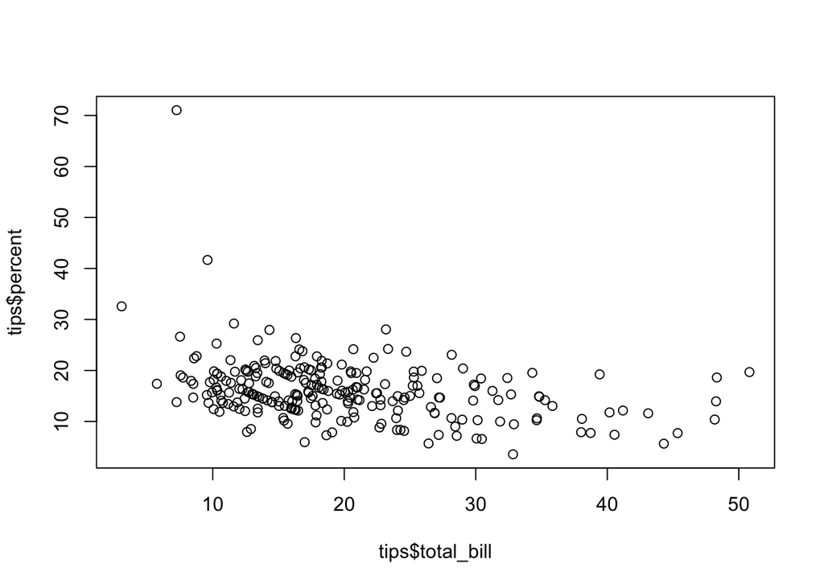

```r
plot(tips$total_bill,tips$percent)
```

## The same plot with some bells and whistles

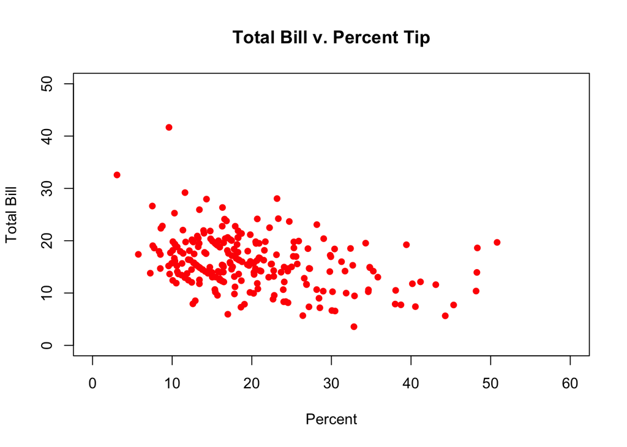

```r
plot(tips$total_bill, tips$percent,
     main = "Total Bill v. Percent Tip", # give plot a title
     xlab = "Percent",    # label the x-axis
     ylab = "Total Bill", # label the y-axis
     pch = 16,            # change the type of plot point
     col = "red",         # set the color of plot point
     lwd = 2,             # set the line width
     xlim = c(0, 60),     # change limits of x-axis
     ylim = c(0,50))      # change the limits of y-axis
```

## You can also just set a few options

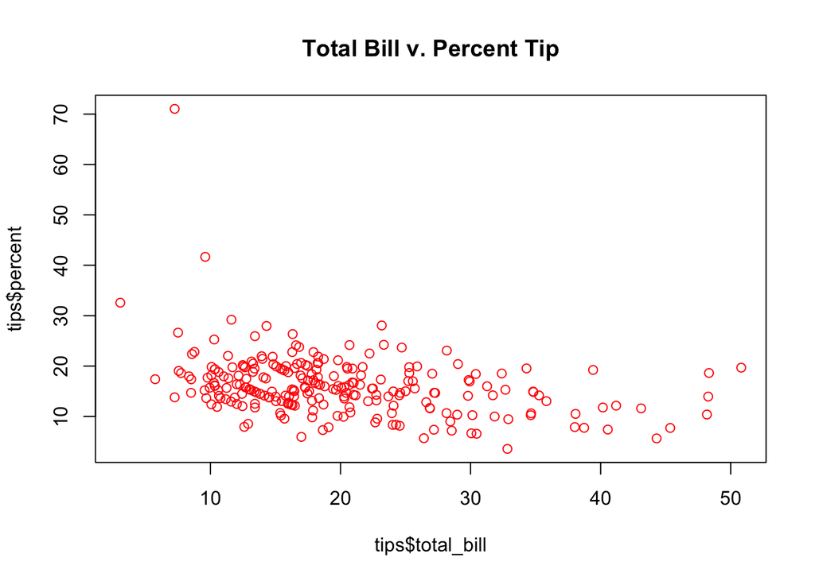

```r
plot(tips$total_bill,
     tips$percent,
     col="red",
     main="Total Bill v. Percent Tip")
```

## A few more useful plot types

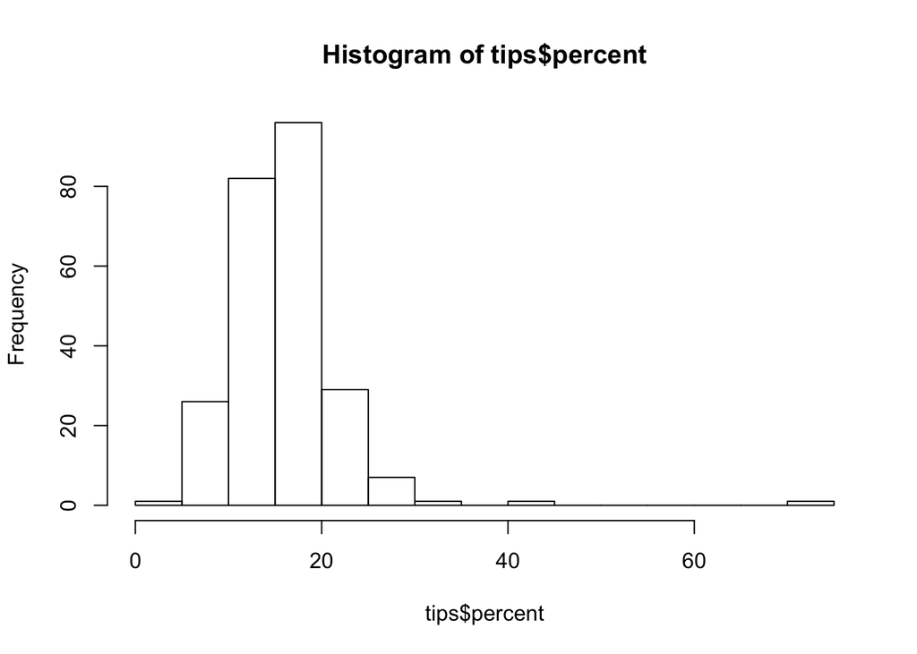

```r
hist(tips$percent, breaks=10)                               # A histogram
```

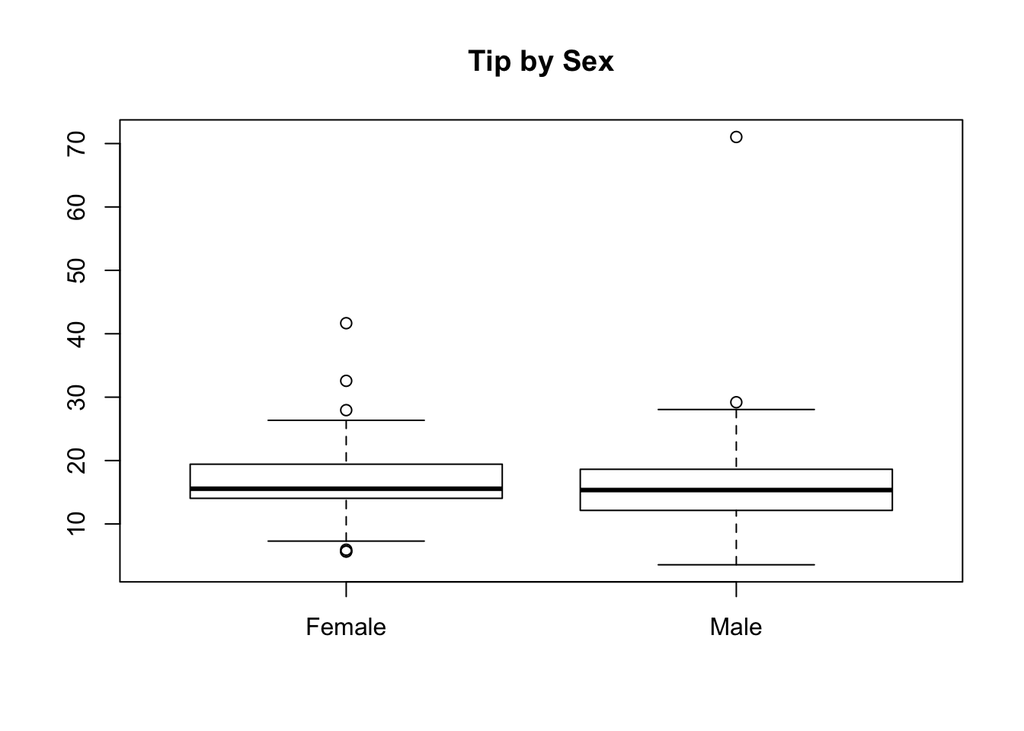

```r
boxplot(tips$percent ~ tips$sex, main = "Tip by Sex")       # A boxplot
```

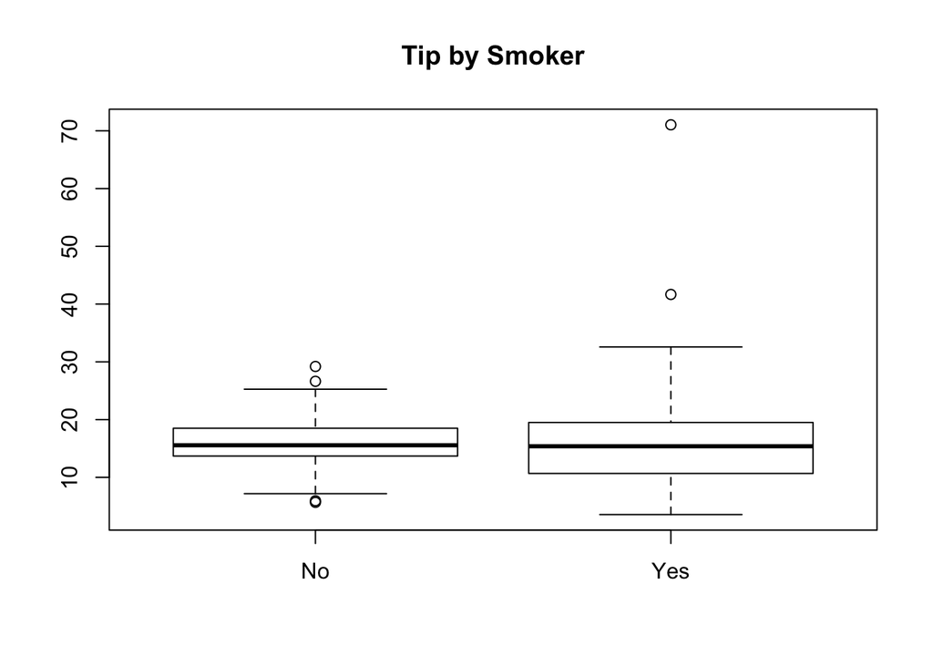

```r
boxplot(tips$percent ~ tips$smoker, main = "Tip by Smoker") # Another boxplot
```

## Saving Plots

```r
pdf("boxplot.pdf") # open pdf graphics device;
                   # analogous commands: jpeg(), png()
boxplot(tips$percent ~ tips$sex) # A boxplot
dev.off()                        # close device and
```

```r
                                 # save plot to pdf
```

## A simple linear regression

```r
model <- lm(percent ~ total_bill, data = tips) # save your regression as an object
model # show modelling results
```

```
##
## Call:
## lm(formula = percent ~ total_bill, data = tips)
##
## Coefficients:
## (Intercept)   total_bill
##     20.6766      -0.2323
```

```r
model.summary <- summary(model) # save the results summary as an object
model.summary # show more detailed results
```

```
##
## Call:
## lm(formula = percent ~ total_bill, data = tips)
##
## Residuals:
##     Min      1Q  Median      3Q     Max
## -10.785  -3.331  -0.332   2.437  52.042
##
## Coefficients:
##             Estimate Std. Error t value Pr(>|t|)
## (Intercept) 20.67658    0.89995  22.975  < 2e-16 ***
## total_bill  -0.23230    0.04149  -5.599 5.85e-08 ***
## ---
## Signif. codes:  0 '***' 0.001 '**' 0.01 '*' 0.05 '.' 0.1 ' ' 1
##
## Residual standard error: 5.758 on 242 degrees of freedom
## Multiple R-squared:  0.1147, Adjusted R-squared:  0.111
## F-statistic: 31.34 on 1 and 242 DF,  p-value: 5.848e-08
```

```r
# model.summary has accessible attributes
names(model.summary)
```

```
##  [1] "call"          "terms"         "residuals"     "coefficients"
##  [5] "aliased"       "sigma"         "df"            "r.squared"
##  [9] "adj.r.squared" "fstatistic"    "cov.unscaled"
```

```r
# an example
model.summary$coefficients # a matrix of the coeffs, SEs, t-stat, p-val
```

```
##               Estimate Std. Error   t value     Pr(>|t|)
## (Intercept) 20.6765807 0.89995494 22.975129 9.479630e-63
## total_bill  -0.2323024 0.04149366 -5.598504 5.848059e-08
```

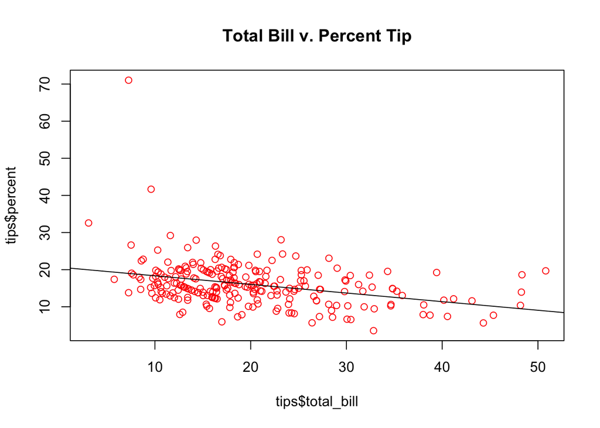

```r
# plotting the results
plot(tips$total_bill,
     tips$percent,
     col="red",
     main="Total Bill v. Percent Tip")
abline(model) # add best fit line
```